# Processamento de Linguagem Natural

Embeddings: texto como ponto no espaço

Wesley Galvão

## Embeddings

O objetivo da aula é usar embeddings para:

- representar um texto pelo **sentido**, não pelas palavras;
- **agrupar** textos parecidos;
- **buscar** pelo sentido: a consulta não precisa ter as palavras do texto.

No laboratório, os mesmos passos com o dataset que você escolher: notícias, filmes e séries ou jogos.

## Jaccard × embedding

Na aula passada, o **Jaccard** comparou textos pelas palavras em comum: similaridade **léxica**.

[figure not shown]

## Embedding

**Embedding.** Um vetor de números que um modelo neural pré-treinado atribui a um texto. Textos de sentido parecido recebem vetores próximos.

[figure not shown]

O mesmo vale para palavras, frases, documentos e imagens (os vetores do DINOv3, na aula de imagens).

## Como o modelo aprende

- **word2vec** (2013): uma rede neural rasa prevê cada palavra pelas vizinhas. Palavras usadas nos mesmos contextos terminam com vetores parecidos.
- **Modelos de frase** (hoje): aprendizado **contrastivo**. Pares de mesmo sentido são aproximados; os demais, afastados.
- Nada é treinado em aula: usamos modelos **pré-treinados**.

[figure not shown]

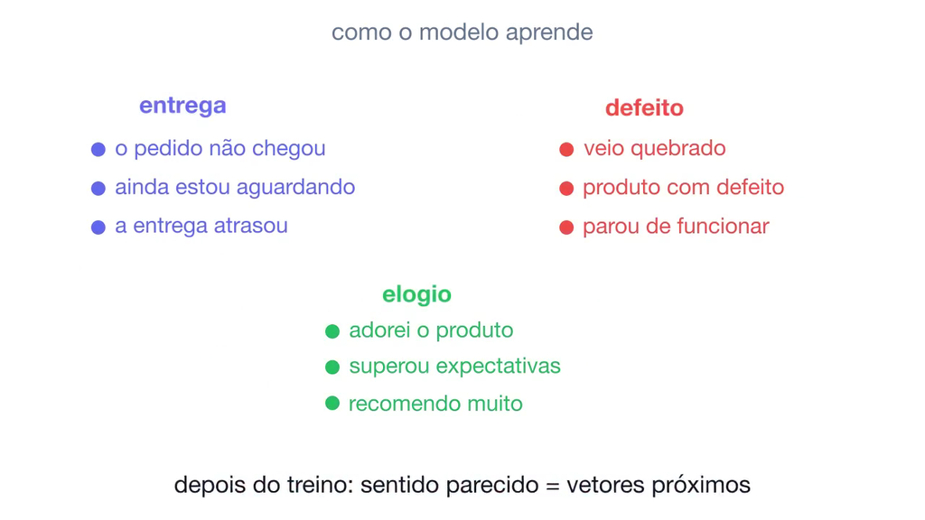

## O vetor por dentro (word2vec)

[figure not shown]

Vetores do word2vec do NILC: cada palavra é um vetor de dimensão 100. Um número sozinho não tem significado; o que conta é o **padrão**: palavras da mesma família têm padrões parecidos.

## O vetor no espaço (word2vec)

[figure not shown]

As mesmas palavras do word2vec: o PCA reduz as 100 dimensões a 2 só para enxergar. Cada família ocupa uma região.

## Similaridade de cosseno

**Cosseno.** Mede o quanto dois vetores $u$ e $v$ apontam na mesma direção (o cosseno do ângulo entre eles): $\cos(u, v) = \dfrac{u \cdot v}{\lVert u \rVert \, \lVert v \rVert}$, em que $u \cdot v$ é o produto escalar (soma dos produtos, número a número) e $\lVert u \rVert$ é o comprimento do vetor.

[figure not shown]

Com vetores de comprimento 1 (normalizados), o cosseno é o próprio produto escalar.

## Operações com vetores (word2vec)

Somar e subtrair vetores é somar e subtrair número a número. A diferença entre dois vetores é uma **direção** no espaço:

[figure not shown]

## Pré-processamento para embeddings

[figure not shown]

O modelo lê a frase inteira: palavras funcionais e negações fazem parte do sentido.

## Onde se usa

[figure not shown]

# Agrupamento

## Grupos de filmes pelo sentido

1. cada sinopse (4.793 filmes do TMDB) vira um vetor de dimensão 1024 (Qwen3);
2. o KMeans separa os vetores em 30 grupos;
3. o UMAP reduz os vetores à dimensão 2, só para desenhar o mapa.

[figure not shown]

## O que tem em cada grupo

[figure not shown]

# Busca semântica

## Buscar pelo sentido

A consulta vira um vetor com o mesmo modelo; a resposta são os textos de maior cosseno.

[figure not shown]

## Banco vetorial

Comparar a consulta com todos os vetores funciona para milhares; para milhões, um **banco vetorial** guarda os vetores num índice de vizinhos aproximados.

[figure not shown]

## Laboratório

Notebook `laboratorio/2_embeddings_de_textos.ipynb` (Colab ou PC):

[figure not shown]

## Os datasets do laboratório: escolha um

[figure not shown]

## O que vira vetor decide o que é parecido

[figure not shown]

## Referências

- Mikolov, T. et al. *Efficient Estimation of Word Representations in Vector Space*. 2013 (word2vec).
- Hartmann, N. et al. *Portuguese Word Embeddings: Evaluating on Word Analogies and Natural Language Tasks*. STIL, 2017 (vetores do NILC).
- Reimers, N.; Gurevych, I. *Sentence-BERT*. EMNLP, 2019 (embeddings de frase, aprendizado contrastivo).
- Zhang, Y. et al. *Qwen3 Embedding*. 2025 (modelo `Qwen/Qwen3-Embedding-0.6B`).
- Caseli, H. M.; Nunes, M. G. V. (org.). *Processamento de Linguagem Natural*, 4ª ed. BPLN, 2026 (semântica distribucional e embeddings).
- Dados: TMDB 5000 (Kaggle); B2W-Reviews01 (Americanas, CC BY-NC-SA 4.0); notícias da Folha de S.Paulo, catálogo da Netflix e jogos da Steam (Kaggle); zvec (Alibaba).